# Project SRE: Part 1 - Seismic Input and Random Vibrations

- Names: Menno Marissen, Gabriele Mylonopoulos, Bart Slingerland and Jerin Thomas
- Student numbers: 5381827, 4807421, 5309913 and 6276423
- Date: 23 June 2025
- Course: Applied Dynamics of Structures - Structural Response to Earthquakes
- Course code: CIEM5220-U1

## Exercise 1: Governing equations of the layered soil system

[figure not shown]

The soil system consists of three layers with indices 1, 2 and 3 in downward direction. The bottom of the third layer is excited by an earthquake that occurs in the bedrock level below. The presence of the offshore wind turbine is disregarded in this question.

### Equations of motion

The equations of motion for all three layers with $m\in(1,2,3)$ are:

$$\rho_m \frac{\partial^2 u_m(z_m,t)}{\partial t^2} - G_m \frac{\partial^2 u_m(z_m,t)}{\partial z^2} - \eta_m \frac{\partial^3 u_m(z_m,t)}{\partial z^2 \partial t} = 0$$

in which $\rho_m$ is the density of the layer [kg/m³], $u_m(z_m,t)$ is the horizontal displacement [m] in the local coordinate system $0<z_m<H_m$ [m], $t$ is the time [s], $G_m$ is the shear modulus of the layer [N/m²], and $\eta_m$ is the damping coefficient [Ns/m²].

The shear stress is given by $\tau_m(z_m,t) = G_m\gamma_m + \eta_m \frac{\partial \gamma_m}{\partial t}$ with $\gamma_m = \frac{\partial u_m}{\partial z}$.

### Boundary conditions

The equations of motion are second-order in space, which means that there should be one boundary condition at the soil surface and one at the base of the multi-layered soil medium.

At the soil surface ($z_1=0$), the shear stress is zero: $$\tau_1(z_1=0,t) = G_1\frac{\partial u_1}{\partial z} + \eta_1 \frac{\partial^2 u_1}{\partial z \partial t} = 0$$

At the base, the ground displacement should match the motion of the base: $$u_3(z_3=H_3,t) = u_0(t)$$

### Interface conditions

Following from the fact that the equations of motion are second-order in space, there should be two interface conditions at each interface. One relates the displacements to each other, while the second one takes care of shear stress equilibrium. Both conditions hold for $m\in(1,2)$.

$$u_m(z_m=H_m,t) = u_{m+1}(z_{m+1}=0,t)$$ $$\tau_m(z_m=H_m,t) = \tau_{m+1}(z_{m+1}=0,t)$$

## Exercise 2: Natural frequencies and modes of vibration

For the system described in Exercise 1, natural frequencies and modes of vibration can be found.

### Converting to the frequency domain

Material damping may be neglected, so $\eta_m=0$; $m\in(1,2,3)$. The equations of motion become (using the previously mentioned values for the index $m$):

$$\rho_m \frac{\partial^2 u_m(z_m,t)}{\partial t^2} - G_m \frac{\partial^2 u_m(z_m,t)}{\partial z^2} = 0$$

with $\tau_m(z_m,t) = G_m \frac{\partial u_m}{\partial z}$. A general solution is expected to be in the form of:

$$u_m(z_m,t) = \tilde{U}_m(z_m,\omega) e^{i\omega t}$$

Substitution of this into the equation of motion converts the problem to the frequency domain and yields:

$$\left(\omega^2 \rho_m \tilde{U}_m(z_m,\omega) + G_m \frac{d^2\tilde{U}_m(z_m,\omega)}{dz^2}\right) e^{i\omega t} = 0$$ $$\frac{d^2\tilde{U}_m(z_m,\omega)}{dz^2} + \frac{\omega^2 \rho_m}{G_m} \tilde{U}_m(z_m,\omega) = 0$$ $$\frac{d^2\tilde{U}_m(z_m,\omega)}{dz^2} + k_m^2 \tilde{U}_m(z_m,\omega) = 0$$

with $k_m^2 = \frac{\omega^2 \rho_m}{G_m} = \frac{\omega^2}{c_m^2}$ with $c_m = \sqrt{\frac{G_m}{\rho_m}}$ and thus $k_m = \pm \frac{\omega}{c_m}$.

A general solution of this new equation is expected to be in the form of:

$$\tilde{U}_m(z_m,\omega) = \tilde{A}_{m,1} e^{ik_m z_m} + \tilde{A}_{m,2} e^{-ik_m z_m}$$

with $k_m = \frac{\omega}{c_m}$, so the negative solution is written as $-k_m$. Only $\tilde{A}_{m,1}$ and $\tilde{A}_{m,2}$ remain unknown for this second-order problem, which can thus be solved for using the two boundary and/or interface conditions per layer.

### Applying boundary conditions

The upper boundary condition: $$\tau_1(z_1=0,t) = G_1\frac{\partial u_1}{\partial z} = 0$$ $$G_1 ik_1(\tilde{A}_{1,1} e^{ik_1 0} - \tilde{A}_{1,2} e^{-ik_1 0}) = 0$$ $$G_1 ik_1(\tilde{A}_{1,1} - \tilde{A}_{1,2}) = 0$$ $$\tilde{A}_{1,1} = \tilde{A}_{1,2}$$

The lower boundary condition: $$u_3(z_3=H_3,t) = u_0(t)$$ $$\left(\tilde{A}_{3,1} e^{ik_3 H_3} + \tilde{A}_{3,2} e^{-ik_3 H_3}\right) e^{i\omega t} = u_0(t)$$

### Applying interface conditions

Equilibrium of displacements: $$u_m(z_m=H_m,t) = u_{m+1}(z_{m+1}=0,t)$$ $$\tilde{U}_m(H_m,\omega) e^{i\omega t} = \tilde{U}_{m+1}(0,\omega) e^{i\omega t}$$ $$\tilde{U}_m(H_m,\omega) = \tilde{U}_{m+1}(0,\omega)$$ $$\tilde{A}_{m,1} e^{ik_m H_m} + \tilde{A}_{m,2} e^{-ik_m H_m} = \tilde{A}_{m+1,1} e^{ik_{m+1} 0} + \tilde{A}_{m+1,2} e^{-ik_{m+1} 0}$$ $$\tilde{A}_{m,1} e^{ik_m H_m} + \tilde{A}_{m,2} e^{-ik_m H_m} = \tilde{A}_{m+1,1} + \tilde{A}_{m+1,2}$$

Equilibrium of shear stresses: $$\tau_m(z_m=H_m,t) = \tau_{m+1}(z_{m+1}=0,t)$$ $$G_m \frac{\partial u_m}{\partial z}\Big|_{z_m=H_m} = G_{m+1} \frac{\partial u_{m+1}}{\partial z}\Big|_{z_{m+1}=0}$$ $$G_m \frac{d\tilde{U}_m(z_m,\omega)}{dz}e^{i\omega t}\Big|_{z_m=H_m} = G_{m+1} \frac{d\tilde{U}_{m+1}(z_{m+1},\omega)}{dz}e^{i\omega t}\Big|_{z_{m+1}=0}$$ $$G_m ik_m\left(\tilde{A}_{m,1} e^{ik_m H_m} - \tilde{A}_{m,2} e^{-ik_m H_m}\right) = G_{m+1} ik_{m+1}\left(\tilde{A}_{m+1,1} e^{ik_{m+1} 0} - \tilde{A}_{m+1,2} e^{-ik_{m+1} 0}\right)$$ $$G_m ik_m\left(\tilde{A}_{m,1} e^{ik_m H_m} - \tilde{A}_{m,2} e^{-ik_m H_m}\right) = G_{m+1} ik_{m+1}\left(\tilde{A}_{m+1,1} - \tilde{A}_{m+1,2}\right)$$ $$\tilde{A}_{m+1,1} - \tilde{A}_{m+1,2} = a_m\left(\tilde{A}_{m,1} e^{ik_m H_m} - \tilde{A}_{m,2} e^{-ik_m H_m}\right)$$

with $a_m = \frac{G_m k_m}{G_{m+1} k_{m+1}}$.

### Combining everything to obtain the solution

Solving the two final equations from the interface conditions for the unknown deeper-layer coefficients $\tilde{A}_{m+1,1}$ and $\tilde{A}_{m+1,2}$ yields:

$$\tilde{A}_{m+1,1} = \frac{1}{2}\tilde{A}_{m,1}(1+a_m)e^{ik_m H_m} + \frac{1}{2}\tilde{A}_{m,2}(1-a_m)e^{-ik_m H_m}$$ $$\tilde{A}_{m+1,2} = \frac{1}{2}\tilde{A}_{m,1}(1-a_m)e^{ik_m H_m} + \frac{1}{2}\tilde{A}_{m,2}(1+a_m)e^{-ik_m H_m}$$

which can be combined with the two previously found boundary conditions: $$\tilde{A}_{1,1} = \tilde{A}_{1,2}$$ $$\left(\tilde{A}_{3,1} e^{ik_3 H_3} + \tilde{A}_{3,2} e^{-ik_3 H_3}\right) e^{i\omega t} = u_0(t)$$

and solved for, to finally be substituted to obtain the final solution: $$u_m(z_m,t) = \tilde{U}_m(z_m,\omega) e^{i\omega t} = \left(\tilde{A}_{m,1} e^{ik_m z_m} + \tilde{A}_{m,2} e^{-ik_m z_m}\right)e^{i\omega t}$$

### Implementation in PyDynSM

The layered soil structure can also be modeled using the PyDynSM Python package. This is done below, using shear beams as the element type of the soil layers.

```python
#Importing packages

import matplotlib.pyplot as plt
import numpy as np
import pydynsm as PDM
import scipy.optimize as opt
from scipy.fft import rfft, rfftfreq
from scipy.optimize import fsolve
from scipy.signal import butter, correlate, filtfilt
from scipy.stats import norm
```

```python
#Defining parameters

student_number = 5381827
student_number = list(str(student_number))
for i in range(len(student_number)):
    student_number[i] = int(student_number[i])
A, B, C, D, E, F, G = student_number

M = (800 + F * 10) * 1E3 #kg
J = 300E6 #kgm²
rho_t = 7850 #kg/m³
E_t = 210E9 #N/m²
D_out = 9.1 #m
D_inner = 8.96 #m
H_t = 140 + A #m
H_w = 30 + F #m
H_1 = 2 + B #m
H_2 = 58 + G #m
H_3 = 38 + F #m
G_1 = (100 + F * 10) * 1E6 #N/m²
rho_1 = 1600 #kg/m³
eta_1 = 1000 + C * 10 #Ns/m²
G_2 = (100 + D * 10) * 1E6 #N/m²
rho_2 = 1900 #kg/m³
eta_2 = 1000 + E * 10 #Ns/m²
G_3 = (100 + E * 10) * 1E6 #N/m²
rho_3 = 2000 #kg/m³
eta_3 = 1000 + D * 10 #Ns/m²

f_max1 = 200 #Hz
omega_range1 = np.linspace(1, f_max1 * 2 * np.pi, 1000)
```

```
Assembler 'Soil' successfully initialised
Successfully added element of type: Shear Beam to Element 0
Successfully added element of type: Shear Beam to Element 1
Successfully added element of type: Shear Beam to Element 2
```

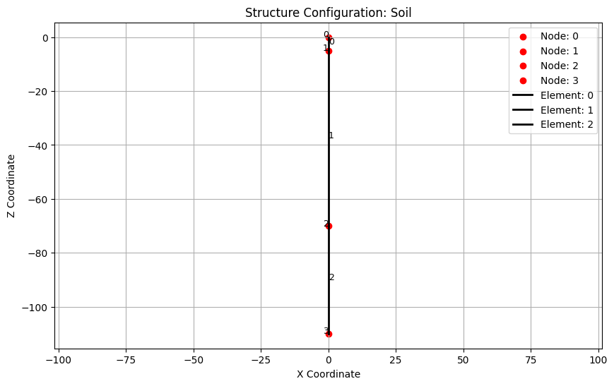

```python
#Creating the layered soil system

#Instantiating class
s1 = PDM.Assembler('Soil')

#Creating nodes
nodes1 = []
H_list1 = [0, -H_1, -(H_1 + H_2), -(H_1 + H_2 + H_3)]

for H in H_list1:
    node = s1.CreateNode(0, H, dof_config=['x'])
    nodes1.append(node)

nodes1[-1].fix_node('x') #x is fixed, because it should be unforced (so no earthquake)

#Creating elements
elems1 = []

rho = [rho_1, rho_2, rho_3]
A_s = 1 #A is divided out of the EoM
G_list = [G_1, G_2, G_3]

for i in range(len(nodes1) - 1):
    elem = s1.CreateElement([nodes1[i], nodes1[i + 1]])
    soil_section_no_damping = {'rho': rho[i], 'A': A_s, 'G': G_list[i]} #no damping, otherwise omegas will be complex, will be added later (ksi=0 by default, see source code: "self.ksi = ksi if ksi is not None else 0")
    elem.SetSection('Shear Beam', soil_section_no_damping)
    elems1.append(elem)

s1.PlotStructure(plot_elements=True)
```

```python
#Some functions needed to find the natural frequencies

def BVP(ww, s):
    return s.GlobalConstrainedStiffness(ww)

def det_func(ww, s):
  return np.linalg.det(BVP(ww, s) / 1e10)

def find_eigen_frequencies(omega, s):
    Det_M = np.array([det_func(ww, s) for ww in omega])
    omega_initial = omega[np.where(np.isclose(abs(np.diff(np.angle(Det_M)))/np.pi,1, atol=.1))[0]]
    omega_m = []
    for ww in omega_initial:
        omega_m.append(opt.newton(det_func,ww,args=(s,),maxiter=2000).real)
    return np.unique(omega_m)

def remove_close_roots(roots, tol=1e-6):
    roots = np.sort(roots)
    filtered_roots = [roots[0]]

    for i in range(1, len(roots)):
        if not np.isclose(roots[i], filtered_roots[-1], atol=tol):
            filtered_roots.append(roots[i])

    return np.array(filtered_roots)
```

```
The first 10 natural frequencies are: [ 0.63562324  2.92014046  4.18691567  6.47751586  7.7312669   8.93687311
 10.03522988 12.49800316 13.59461092 16.05221878]
```

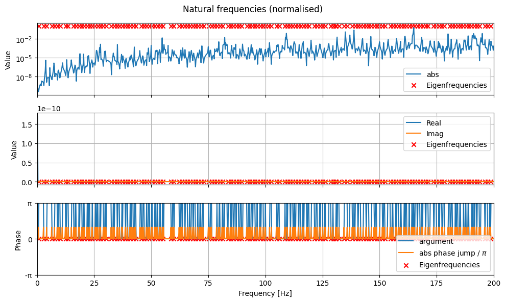

```python
#Finding the natural frequencies and visualising that process and the results

s1.run_connectivity()

omega_m1 = np.array(find_eigen_frequencies(omega_range1, s1))
omega_m1 = remove_close_roots(omega_m1)
f_m1 = omega_m1 / (2 * np.pi)

Det_M1 = np.array([det_func(omega, s1) for omega in omega_range1])
arg_dets1 = np.angle(Det_M1)

fig, axs = plt.subplots(3, sharex=True, figsize=(10,6))
axs[0].semilogy(omega_range1 / 2 / np.pi, abs(Det_M1), label='abs')
axs[1].plot(omega_range1 / 2 / np.pi, Det_M1.real/omega_range1**6, label='Real')
axs[1].plot(omega_range1 / 2 / np.pi, Det_M1.imag/omega_range1**6, label='Imag')
axs[2].plot(omega_range1 / 2 / np.pi, arg_dets1, label='argument')
axs[2].plot(omega_range1[:-1] / 2 / np.pi, abs(np.diff(arg_dets1))/np.pi, label='abs phase jump / $\\pi$')
axs[2].set_ylim([-np.pi, np.pi])

axs[0].scatter(f_m1, np.ones_like(omega_m1), marker='x', c='r', label='Eigenfrequencies')
axs[1].scatter(f_m1, np.zeros_like(omega_m1), marker='x', c='r', label='Eigenfrequencies')
axs[2].scatter(f_m1, np.zeros_like(omega_m1), marker='x', c='r', label='Eigenfrequencies')

for ax in axs:
    ax.grid()
    ax.legend()
    ax.set_xlim([0, f_max1])
axs[0].set_ylabel('Value')
axs[1].set_ylabel('Value')
axs[2].set_ylabel('Phase')
axs[2].set_xlabel('Frequency [Hz]')
axs[2].set_yticks([-np.pi, 0, np.pi], ['-$\\mathrm{\\pi}$', 0, '$\\mathrm{\\pi}$'])
fig.suptitle('Natural frequencies (normalised)')
plt.tight_layout()

N = 10
print(f'The first {N} natural frequencies are: {f_m1[:N]}')
```

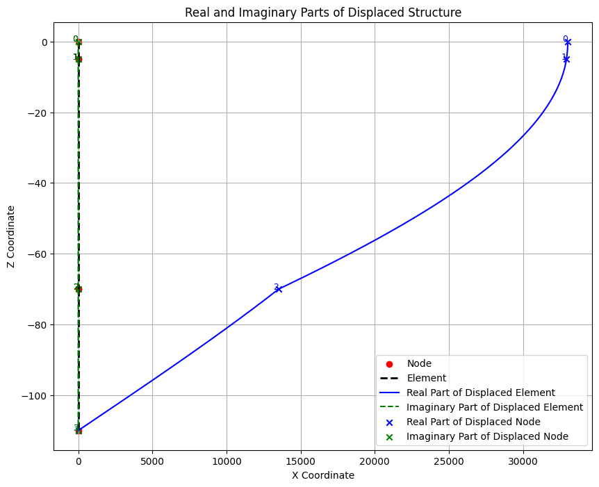

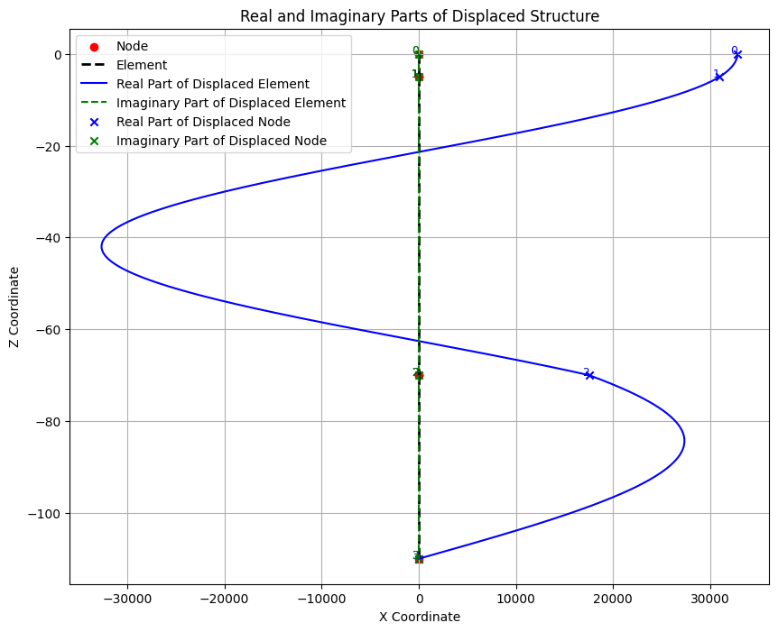

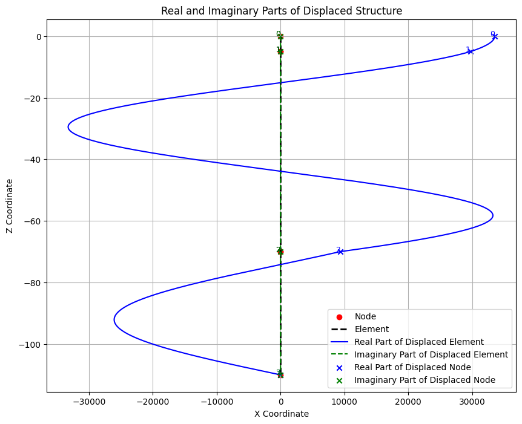

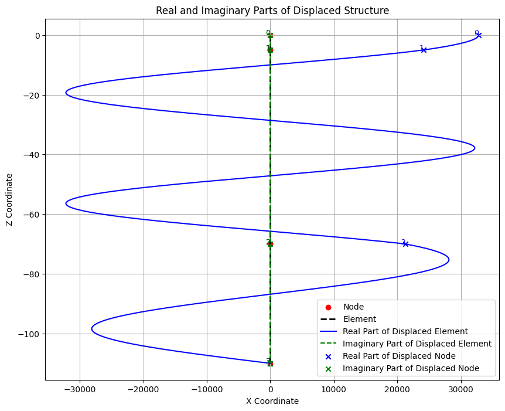

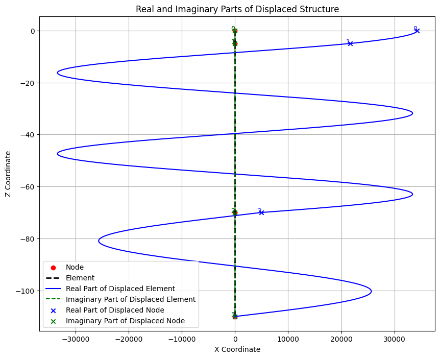

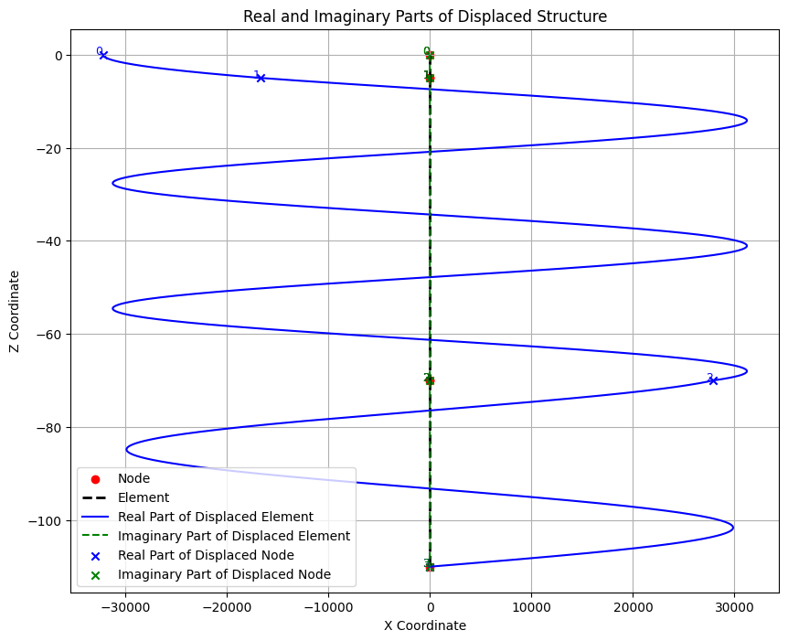

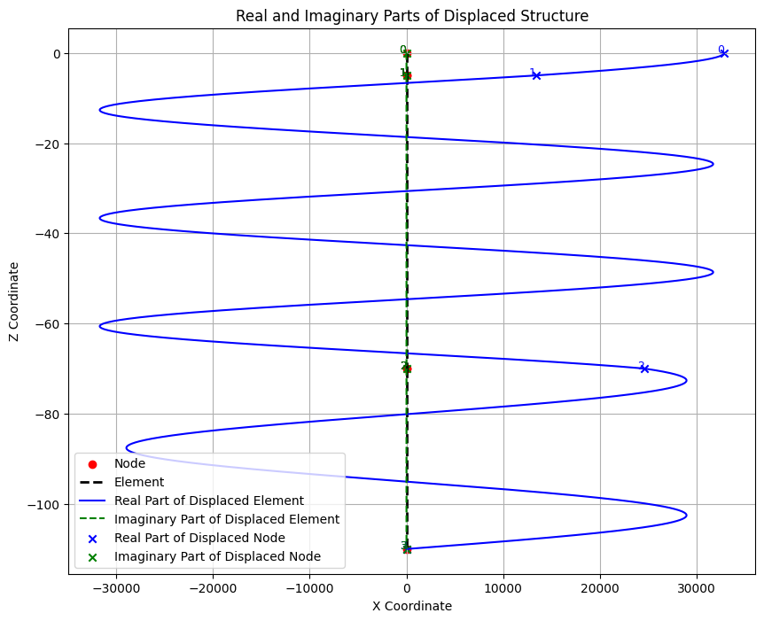

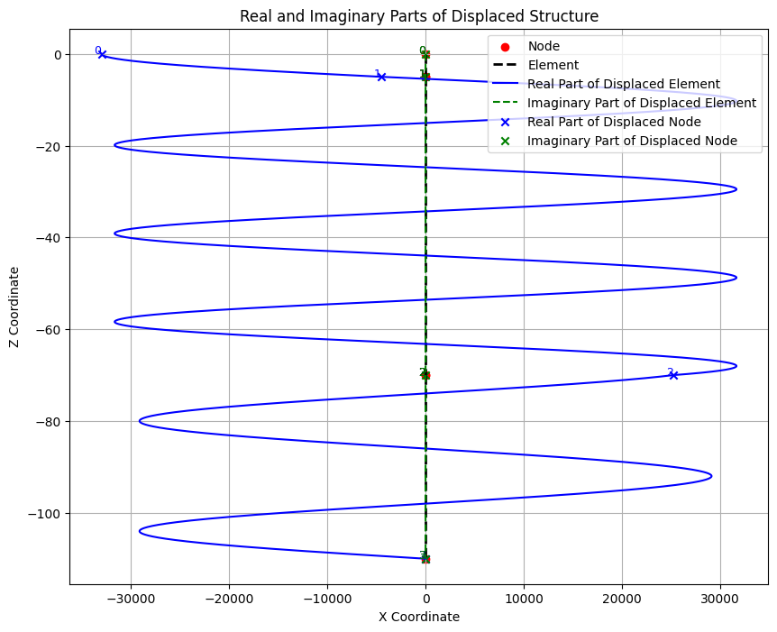

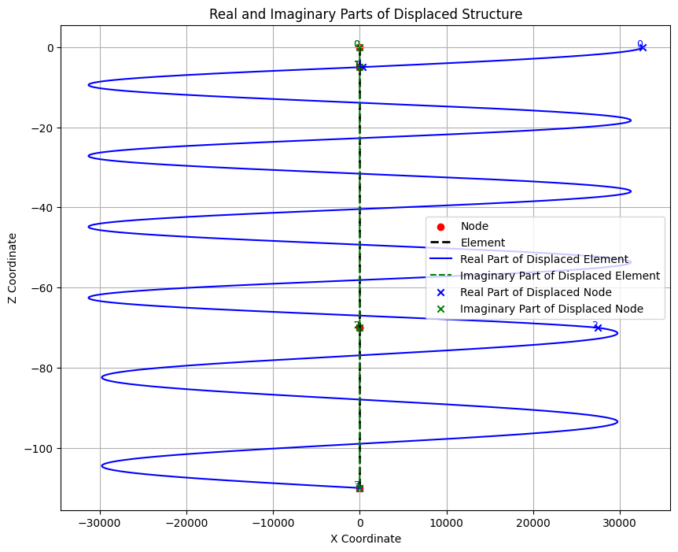

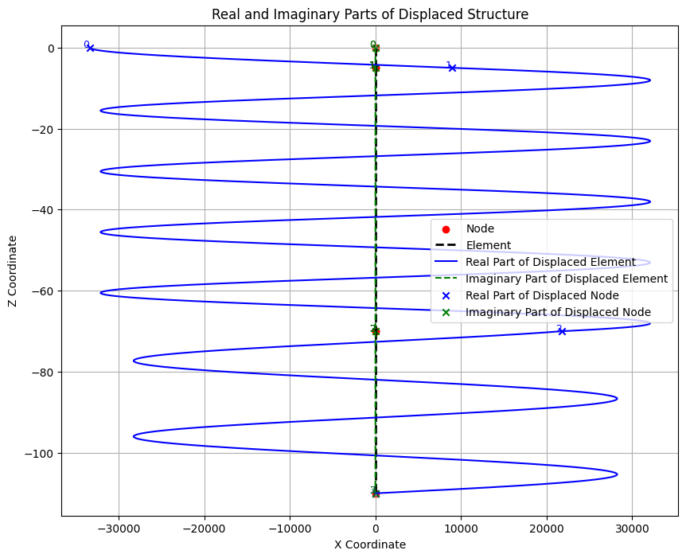

```python
#Normalising the modes of vibration and plotting the first 10

def get_local_coordinates(elements,num):
    coor_local = {}
    for element in elements:
        coor_local[element.id] = element.L*np.linspace(0,1,num)
    return coor_local

def Normalize_modes(Omega, displacement, displacement_local, local_coordinates, elements):
    disp_norm = {}
    disp_local_norm = {}
    for omega in Omega:
        Gamma = 0
        for element in elements:
            key = list(element.element_types.keys())[0]
            rho = element.element_types[key].rho
            A = element.element_types[key].A
            Gamma += rho * A * np.trapezoid(displacement_local[omega][element.id][1]**2, local_coordinates[element.id])

        disp_norm[omega] = {elem: disp / np.sqrt(Gamma) for elem, disp in displacement[omega].items()}
        #Local normalised displacements
        disp_local_norm[omega] = {elem: disp / np.sqrt(Gamma) for elem, disp in displacement_local[omega].items()}
    return disp_norm, disp_local_norm

#firstly create a dictionary for storing the displacements of each mode
disp_dict = {}
disp_local_dict = {}
num = 8000
for omega in omega_m1:
    Kc_global = s1.GlobalConstrainedStiffness(omega)
    u_free = s1.SolveUfree(Kc_global[:-1,:-1], -Kc_global[:-1,-1])
    u_free = np.concatenate((u_free, np.array([1])))
    u_elem = s1.FullDisplacement(u_free)
    disp = s1.ElementDisplacements(u_elem, omega, num)
    disp_dict[omega] = disp
    # get local displacements
    disp_local = s1.ElementDisplacements(u_elem, omega,num,local_axes=True)
    disp_local_dict[omega] = disp_local

local_coordinates = get_local_coordinates(elems1, num)
disp_norm, disp_local_norm = Normalize_modes(omega_m1, disp_dict, disp_local_dict, local_coordinates, elems1)

for omega in omega_m1[:10]:
    s1.PlotElementDisplacements(disp_norm[omega], scale=1e7)
```

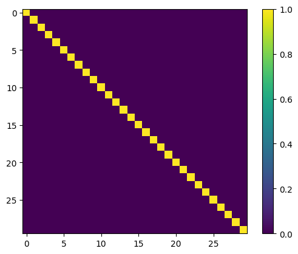

```python
#Checking the orthogonality of the modes

def Check_Orthogonality(omega, disp_local_norm, local_coordinates, elements):
    N = len(omega)
    Ortho_matrix = np.zeros((N, N), dtype=complex)
    for ii, omega_1 in enumerate(omega):
        for jj, omega_2 in enumerate(omega):
            for element in elements:
                key = list(element.element_types.keys())[0]
                rho = element.element_types[key].rho
                A = element.element_types[key].A
                Ortho_matrix[ii, jj] += rho * A * np.trapezoid(disp_local_norm[omega_1][element.id][1] * disp_local_norm[omega_2][element.id][1], local_coordinates[element.id])
    return Ortho_matrix

Ortho_coeff = Check_Orthogonality(omega_m1[:30], disp_local_norm, local_coordinates, elems1)

plt.imshow(abs(Ortho_coeff))
plt.colorbar();
```

In case soil damping is included, the natural frequencies become complex and the modes of vibration will be damped (modal damping). The PyDynSM package does not support that, because it finds the natural frequencies using the phase shifts in the argument of the determinant of the global stiffness matrix for specific omegas. The damping influences the phase shift, which is why this method is not able to locate natural frequencies when damping is included.

## Exercise 3: Frequency response functions

To find the frequency response functions (FRFs) of the layered soil system, it will be subjected to a unit amplitude earthquake motion (displacement-wise). The response at the top of layer 1 and at the top of layer 3 will be calculated. The maximum considered frequency was chosen as 100 Hz, to find a balance between completeness and the ability to visualise the results.

From now on, material damping will be considered. This is incorporated in the model using material damping according to:

$$\tilde{G} = G(1 + 2\xi i)$$

in which $\xi$ is the material loss factor [-], $i$ the imaginary unit and $G$ is the shear modulus [MPa]. The material loss factor can be determined as:

$$\xi = \frac{\eta \omega}{2G}$$

in which $\eta$ is the provided damping coefficient in Ns/m² and $\omega$ is chosen as the first natural (angular) frequency.

```python
#Finding the responses of the specific degrees of freedom in a certain frequency range

FRF_seism_freq_max = 100
FRF_seism_freq = np.linspace(1, FRF_seism_freq_max, 500)
FRF_seism_omega = FRF_seism_freq * 2 * np.pi
FRF_seism_toplayer1 = np.zeros(len(FRF_seism_omega), dtype=complex)
FRF_seism_toplayer3 = np.zeros(len(FRF_seism_omega), dtype=complex)

#Adding a unit displacement at the bottom of the lowest layer
nodes1[-1].prescribe_node(x=1)

#Adding non-zero damping now
eta = [eta_1, eta_2, eta_3]
for i,elem in enumerate(elems1):
    soil_section_damping = {'rho': rho[i], 'A': A_s, 'G': G_list[i], 'ksi': eta[i] * omega_m1[0] / (2 * G_list[i])} #first natural (angular) frequency is used, damping is very low though: xi is in the order 1e-5 [-]
    elem.SetSection('Shear Beam', soil_section_damping)

s1.run_connectivity() #this is needed after fixing a node

for i,omega in enumerate(FRF_seism_omega):
    Kc_global = s1.GlobalConstrainedStiffness(omega)
    Fc_global = s1.GlobalConstrainedForce(omega)
    u_free = s1.SolveUfree(Kc_global, Fc_global)
    #first free dof (index 0) is the x-displacement of node 1 (index 0)
    FRF_seism_toplayer1[i] = u_free[0]
    #third free dof (index 2) is the x-displacement of node 3 (index 2)
    FRF_seism_toplayer3[i] = u_free[2]
```

```
Successfully added element of type: Shear Beam to Element 0
Successfully added element of type: Shear Beam to Element 1
Successfully added element of type: Shear Beam to Element 2
```

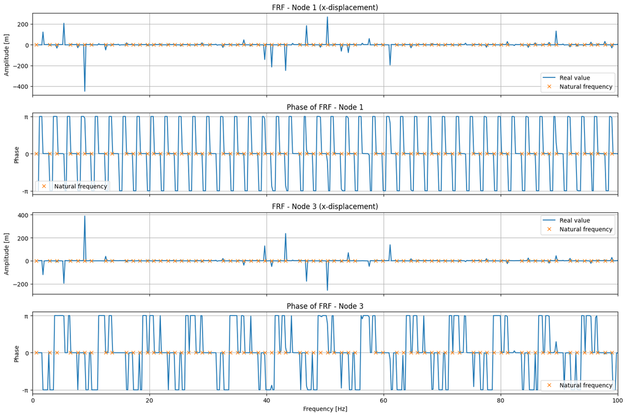

```python
#Plotting the FRFs

f_m_below_f_max_FRF = f_m1[f_m1 < FRF_seism_freq_max]
fig, axes = plt.subplots(4, 1, figsize=(15, 10), sharex=True)
axes[0].plot(FRF_seism_freq, np.real(FRF_seism_toplayer1), label='Real value')
# axes[0].plot(FRF_seism_freq, np.imag(FRF_seism_toplayer1), label='Imaginary value')
# axes[0].plot(FRF_seism_freq, np.abs(FRF_seism_toplayer1), label='Absolute value')
axes[0].set_title('FRF - Node 1 (x-displacement)')
axes[0].set_ylabel('Amplitude [m]')

axes[1].plot(FRF_seism_freq, np.angle(FRF_seism_toplayer1))
axes[1].set_title('Phase of FRF - Node 1')

axes[2].plot(FRF_seism_freq, np.real(FRF_seism_toplayer3), label='Real value')
# axes[2].plot(FRF_seism_freq, np.imag(FRF_seism_toplayer3), label='Imaginary value')
# axes[2].plot(FRF_seism_freq, np.abs(FRF_seism_toplayer3), label='Absolute value')
axes[2].set_title('FRF - Node 3 (x-displacement)')
axes[2].set_ylabel('Amplitude [m]')

axes[3].plot(FRF_seism_freq, np.angle(FRF_seism_toplayer3))
axes[3].set_title('Phase of FRF - Node 3')
axes[3].set_xlabel('Frequency [Hz]')

for i in [1, 3]:
    axes[i].set_ylabel('Phase')
    axes[i].set_ylim([-1.1 * np.pi, 1.1 * np.pi])
    axes[i].set_yticks([-np.pi, 0, np.pi], ['-$\\mathrm{\\pi}$', 0, '$\\mathrm{\\pi}$'])

for ax in axes:
    ax.plot(f_m_below_f_max_FRF, np.zeros(len(f_m_below_f_max_FRF)), 'x', label='Natural frequency')
    ax.legend(loc='best')
    ax.set_xlim(0, FRF_seism_freq_max)
    ax.grid()

fig.tight_layout()
```

The frequency response functions of both node 1 and node 3 show large (displacement) amplifications for certain frequencies. It can be seen that those frequencies are almost the same frequencies for both cases: roughly speaking, a group at frequencies around 0-10 Hz, a group around 40-60 Hz and a few peaks between 80 and 100 Hz. Most of the larger amplifications have a different sign for both nodes, which can be explained by the fact that the mode shapes peak at those nodes, but have a different sign only. Most amplifications occur at a natural frequency (two peaks between 0 and 10 Hz and two peaks around 60 Hz do not). The fact that some frequencies only show a peak at one of the nodes can be explained by the corresponding mode shape (of that natural frequency) having a node (zero amplitude) at the other node.

The plotted phase plots show whether the two nodes move in-phase or out-of-phase with each other, i.e. whether their displacement is in the same or in a different direction. For frequencies where both plots show the same phase or one shows $\pi$ and the other shows $-\pi$, the movements are in-phase. In other cases, the movements are out-of-phase.

## Exercise 4: Governing equations of the offshore wind turbine

The offshore wind turbine can be split up into two segments: the top segment (above the water surface) and the submerged segment. The top part is not subjected to any loading (wind force is not considered here), the lower part is excited by sea waves.

### Equations of motion

Both sections can be modelled as an Euler-Bernoulli beam. The equation of motion for the top segment is:

$$\rho_t A_t \frac{\partial^2 w_1(z,t)}{\partial t^2} + E_t I_t \frac{\partial^4 w_1(z,t)}{\partial z^4} = 0$$

in which $\rho_t$ is the density of the turbine [kg/m³], $A_t$ is the cross-sectional area of the turbine [m²], $w_1(z,t)$ is the horizontal displacement [m] on the interval $H_w<z<H_w + H_t$, $t$ is the time [s], $E_t$ is the Young's modulus of the turbine [N/m²] and $I_t$ its moment of inertia [m⁴].

The equation of motion for the segment submerged in water is:

$$\rho_t A_t \frac{\partial^2 w_2(z,t)}{\partial t^2} + E_t I_t \frac{\partial^4 w_2(z,t)}{\partial z^4} = f_H(z,t)$$

in which $w_2(z,t)$ is the horizontal displacement [m] on the interval $0<z<H_w$ [m] and $f_H(z,t)$ the distributed wave force acting on the turbine [N/m].

The following expressions are used: $A_t=\frac{1}{4}\pi(D_{out}^2-D_{inner}^2)$ and $I_t=\frac{\pi}{64}(D_{out}^4-D_{inner}^4)$. For the wave forces acting on the turbine, Morison equation can be used, using only the inertial part, which is given by: $$f_H(z,t) = \frac{1}{4}\pi D^2\rho_w\frac{\partial u}{\partial t} + \frac{1}{4}\pi D^2C_a\rho_w\left(\frac{\partial u}{\partial t} - \frac{\partial^2 w_2}{\partial t^2}\right)$$

in which $D$ is an equivalent diameter of displaced mass, $\rho_w$ is the density of water, $u$ is the velocity of the waves [m/s] and $C_a$ is an additional mass factor. When implementing this force, the details will be elaborated.

The rotation of an Euler-Bernoulli beam is given by $\varphi(z,t)=-\frac{\partial u}{\partial z}$, the bending moment by $M(z,t)=-E_tI_t\frac{\partial^2 u}{\partial z^2}$ and the shear force by $V(z,t)=-E_tI_t\frac{\partial^3 u}{\partial z^3}$.

### Boundary conditions

The equations of motion are fourth-order in space, which means that there should be two boundary condition at the soil surface and two at the top of the offshore wind turbine.

At the soil surface ($z=0$), a rigid connection with the soil (excited by waves) can be assumed, with no relative displacement. Soil-structure interaction is neglected: $$w_2(z=0,t) = u_1(z_1=0,t)$$

Secondly, the rotation is zero: $$-\frac{\partial w_2}{\partial z}\Big|_{z=0} = 0$$

At the top, the top mass with mass $M$ and rotational inertia $J$ can be incorporated as follows:

[figure not shown]

$$M\frac{\partial^2 w_1}{\partial t^2}\Big|_{z=H_w+H_t}=\sum_i F_i \rightarrow M\frac{\partial^2 w_1}{\partial t^2}\Big|_{z=H_w+H_t} = E_tI_t\frac{\partial^3 w_1}{\partial z^3}\Big|_{z=H_w+H_t}$$ $$J\frac{\partial^3 w_1}{\partial z \partial t^2}\Big|_{z=H_w+H_t}=\sum_i M_i \rightarrow J\frac{\partial^3 w_1}{\partial z \partial t^2}\Big|_{z=H_w+H_t} = E_tI_t\frac{\partial^2 w_1}{\partial z^2}\Big|_{z=H_w+H_t}$$

[figure not shown]

### Interface conditions

Following from the fact that the equations of motion are fourth-order in space, there should be four interface conditions at the interface, which is at sea surface. All four field variables can be equated to each other (in which minus signs and the bending stiffness can be divided out):

$$w_1(z=H_w,t) = w_2(z=H_w,t)$$ $$\frac{\partial w_1}{\partial{z}}\Big|_{z=H_w} = \frac{\partial w_2}{\partial{z}}\Big|_{z=H_w}$$ $$\frac{\partial^2 w_1}{\partial{z^2}}\Big|_{z=H_w} = \frac{\partial^2 w_2}{\partial{z^2}}\Big|_{z=H_w}$$ $$\frac{\partial^3 w_1}{\partial{z^3}}\Big|_{z=H_w} = \frac{\partial^3 w_2}{\partial{z^3}}\Big|_{z=H_w}$$

## Exercise 5: Dynamical response of the offshore wind turbine

### Defining the forcing

The offshore wind turbine is subjected to two loads: the wave force which is directly acting on the structure and the seismic motion at bedrock level (indirectly). They can be assumed uncorrelated.

#### Wave force

The power spectral density of the wave force can be determined using the JONSWAP spectrum, which is given by:

$$S = \alpha g^2 (2\pi)^{-4} f^{-5} e^{-\beta\left(\frac{f}{f_p}\right)^{-4}}\gamma^{e^{-\frac{1}{2}\Big(\frac{\frac{f}{f_p}-1}{\sigma}\Big)^2}}$$

in which:

- $\alpha = 0.076\tilde{F}^{-0.22}$
- $g = 9.81$ [m/s²]
- $f$: frequency
- $\beta = \frac{5}{4}$
- $f_p$: peak frequency
- $\gamma = 3.3$
- $\sigma = \begin{cases} 0.07 & f\leq f_p \\ 0.09 & f> f_p \end{cases}$

For the calculation of $f_p$ using the non-dimensional peak frequency $\tilde{f}_p$ and the non-dimensional fetch $\tilde{F}$, the following three formulas are used:

- $\tilde{f}_p = \frac{U_{10} f_p}{g} \rightarrow f_p = \frac{\tilde{f}_p g}{U_{10}}$
- $\tilde{F} = \frac{gF}{U_{10}^2}$
- $\tilde{f}_p = 3.5\tilde{F}^{-0.33}$

with $U_{10}$ the average wind speed at a reference height of 10 meter [m/s] and fetch $F$ [m]. The parameters from load case 2 of the assignment of Unit 2 of this course (Dynamics of Structures Subjected to Wind & Waves) can be used:

- $U_{10} = 23$ [m/s]
- $F = 200\cdot10^3$ [m]

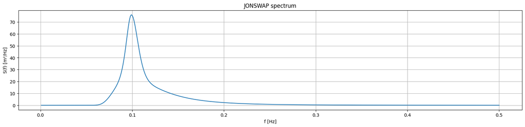

```python
#Defining the power spectral density for the wave force (JONSWAP spectrum)

g = 9.81 #m/s²
beta = 5 / 4
gamma = 3.3
sigma_l = 0.07
sigma_u = 0.09
U_10 = 23 #m/s
F = 200E3 #m
f_max_JS = 0.5 #Hz

F_tilde = g * F / U_10**2
f_p_tilde = 3.5 * F_tilde**(-0.33)
f_p = f_p_tilde * g / U_10
alpha = 0.076 * F_tilde**(-0.22)

freq_waves = np.linspace(0.001, f_max_JS, 500)

def JONSWAP(f):
    sigma = sigma_l * np.ones_like(f)
    sigma[f > f_p] = sigma_u
    return alpha * g**2 * (2 * np.pi)**(-4) * f**(-5) * np.exp(-beta * (f / f_p)**(-4)) * gamma**np.exp(-1 / 2 * ((f / f_p - 1) / sigma)**2)

plt.figure(figsize=(20, 4))
plt.plot(freq_waves, JONSWAP(freq_waves))
plt.title('JONSWAP spectrum')
plt.xlabel('f [Hz]')
plt.ylabel('S(f) [m²/Hz]')
plt.grid()
```

#### Seismic motion

The seismic motion at bedrock level can be taken as the principal horizontal component of a Groningen signal at approximately 100 meter depth that took place on 8 January 2018. Its power spectral density was already provided in the notebook `PSD.ipynb` and is repeated here. For the plots of the (filtered) FFT magnitude spectrum and the auto-correlation function, the reader is referred to the provided notebook.

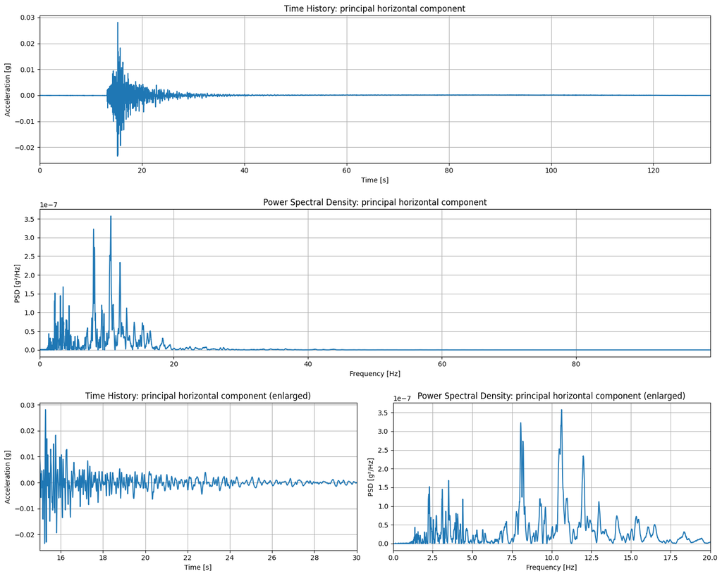

```python
#Defining the power spectral density for the seismic motion

file_path = 'NL.G192..ALL.2018-01-08.dat'
data = np.loadtxt(file_path)

time = data[:, 0]
accel = data[:, 1]
name = 'principal horizontal component'

N = len(accel)
dt = time[1] - time[0]
fs = 1/dt
cutoff = 0.1
order = 4

# Apply high-pass filter to remove low frequency oscillation
nyq = 0.5 * fs           # Nyquist frequency
normal_cutoff = cutoff / nyq
b, a = butter(order, normal_cutoff, btype='high', analog=False)
accel_filtered = filtfilt(b, a, accel)

# Calculate correlation
corr = correlate(accel_filtered, accel_filtered, mode='full') * dt # dt as the definition is the integral over time
lags = np.arange(-len(accel_filtered) + 1, len(accel_filtered)) * dt

# divide by total bin length
normalization = np.array([N - abs(lag) for lag in range(-N + 1, N)]) * dt # dt here such to divide each point by total time T(tau) dependent on the finite signal (t2-t1)
corr = corr / normalization

# Power Spectral Density as fourier transform of the correlation function
N_psd = len(corr)
PSD_seism_0 = abs(rfft(corr)) * dt # no multiplication with 2 due to using negative lag as well, just dt to get /Hz
freq_seism = rfftfreq(len(corr), dt)

# plot
fig = plt.figure(figsize=(15, 12))
ax1 = plt.subplot2grid((3, 2), (0, 0), colspan=2)
ax2 = plt.subplot2grid((3, 2), (1, 0), colspan=2)
ax3 = plt.subplot2grid((3, 2), (2, 0))
ax4 = plt.subplot2grid((3, 2), (2, 1))

ax1.plot(time, accel)
ax1.set_title(f'Time History: {name}')
ax1.set_xlabel('Time [s]')
ax1.set_ylabel('Acceleration [g]')
ax1.set_xlim(0, time[-1])
ax1.grid(True)

ax2.plot(freq_seism, PSD_seism_0)
ax2.set_title(f"Power Spectral Density: {name}")
ax2.set_xlabel("Frequency [Hz]")
ax2.set_ylabel("PSD [g²/Hz]")
ax2.set_xlim(0, freq_seism[-1])
ax2.grid(True)

ax3.plot(time, accel)
ax3.set_title(f'Time History: {name} (enlarged)')
ax3.set_xlabel('Time [s]')
ax3.set_ylabel('Acceleration [g]')
ax3.set_xlim(15, 30)
ax3.grid(True)

ax4.plot(freq_seism, PSD_seism_0)
ax4.set_title(f"Power Spectral Density: {name} (enlarged)")
ax4.set_xlabel("Frequency [Hz]")
ax4.set_ylabel("PSD [g²/Hz]")
ax4.set_xlim(0, 20)
ax4.grid(True)
plt.tight_layout()
```

### Implementation of the offshore wind turbine in PyDynSM

The offshore wind turbine can be modeled using the PyDynSM Python package. This is done below, using "EulerBernoulli Beam foundation attachments" as element type.

```
Assembler 'OWT' successfully initialised
Successfully added element of type: EulerBernoulli Beam to Element 3
Successfully added element of type: EulerBernoulli Beam foundation attachments to Element 4
```

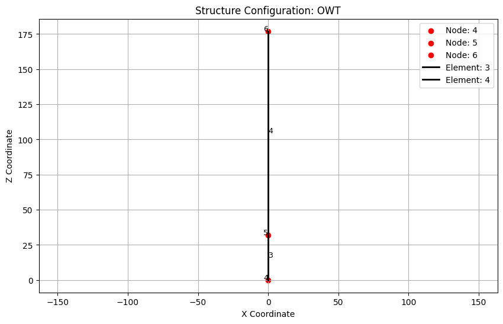

```python
#Creating the offshore wind turbine

#Instantiating class
s2 = PDM.Assembler('OWT')

#Creating nodes
nodes2 = []
H_list2 = [0, H_w, H_w + H_t]

for H in H_list2:
    node = s2.CreateNode(0, H, dof_config=['x', 'phi_y'])
    nodes2.append(node)

nodes2[0].fix_node('x', 'phi_y') #x is fixed, because it should be unforced (so no earthquake)

#Creating elements
elems2 = []

A_t = 1 / 4 * np.pi * (D_out**2 - D_inner**2)
I_t = 1 / 64 * np.pi * (D_out**4 - D_inner**4)
W_t = E_t * I_t / 10
owt_section1 = {'rho': rho_t, 'A': A_t, 'E': E_t, 'Ib': I_t, 'Wb': W_t} #no damping, otherwise omegas will be complex (ksi=0 by default, see source code: "self.ksi = ksi if ksi is not None else 0")
owt_section2 = owt_section1.copy()
owt_section2['Pm2'] = M
owt_section2['J2'] = J

elems2.append(s2.CreateElement([nodes2[0], nodes2[1]]))
elems2[-1].SetSection('EulerBernoulli Beam', owt_section1)
elems2.append(s2.CreateElement([nodes2[1], nodes2[2]]))
elems2[-1].SetSection('EulerBernoulli Beam foundation attachments', owt_section2)

s2.PlotStructure(plot_elements=True)

f_max2 = 400 #Hz
omega_range2 = np.linspace(1, f_max2 * 2 * np.pi, 1000)
```

```
The first 10 natural frequencies are: [  0.58428912   3.02026855   6.30726849  12.08006804  20.57523125
  31.57105613  45.11912835  61.14139408  79.63774973 100.6064627 ]
```

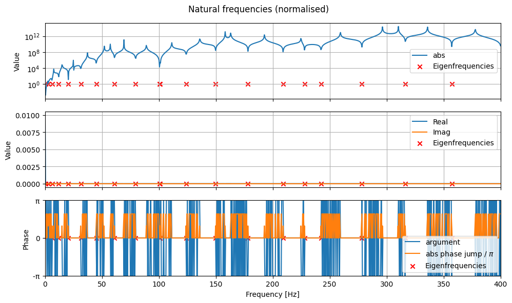

```python
#Finding the natural frequencies and visualising that process and the results

s2.run_connectivity()

omega_m2 = np.array(find_eigen_frequencies(omega_range2, s2))
omega_m2 = remove_close_roots(omega_m2)
f_m2 = omega_m2 / (2 * np.pi)

Det_M2 = np.array([det_func(omega, s2) for omega in omega_range2])
arg_dets2 = np.angle(Det_M2)

fig, axs = plt.subplots(3, sharex=True, figsize=(10,6))
axs[0].semilogy(omega_range2 / 2 / np.pi, abs(Det_M2), label='abs')
axs[1].plot(omega_range2 / 2 / np.pi, Det_M2.real/omega_range2**6, label='Real')
axs[1].plot(omega_range2 / 2 / np.pi, Det_M2.imag/omega_range2**6, label='Imag')
axs[2].plot(omega_range2 / 2 / np.pi, arg_dets2, label='argument')
axs[2].plot(omega_range2[:-1] / 2 / np.pi, abs(np.diff(arg_dets2))/np.pi, label='abs phase jump / $\\pi$')
axs[2].set_ylim([-np.pi, np.pi])

axs[0].scatter(f_m2, np.ones_like(omega_m2), marker='x', c='r', label='Eigenfrequencies')
axs[1].scatter(f_m2, np.zeros_like(omega_m2), marker='x', c='r', label='Eigenfrequencies')
axs[2].scatter(f_m2, np.zeros_like(omega_m2), marker='x', c='r', label='Eigenfrequencies')

for ax in axs:
    ax.grid()
    ax.legend()
    ax.set_xlim([0, f_max2])
axs[0].set_ylabel('Value')
axs[1].set_ylabel('Value')
axs[2].set_ylabel('Phase')
axs[2].set_xlabel('Frequency [Hz]')
axs[2].set_yticks([-np.pi, 0, np.pi], ['-$\\mathrm{\\pi}$', 0, '$\\mathrm{\\pi}$'])
fig.suptitle('Natural frequencies (normalised)')
plt.tight_layout()

N = 10
print(f'The first {N} natural frequencies are: {f_m2[:N]}')
```

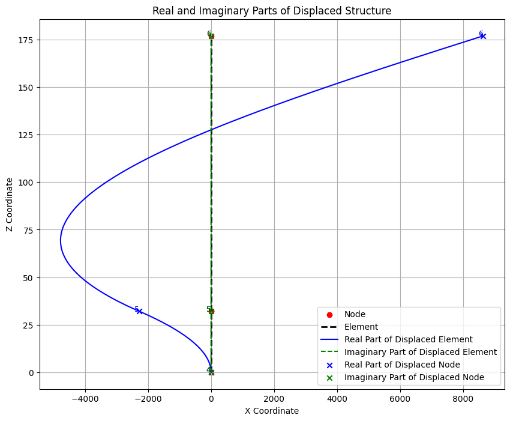

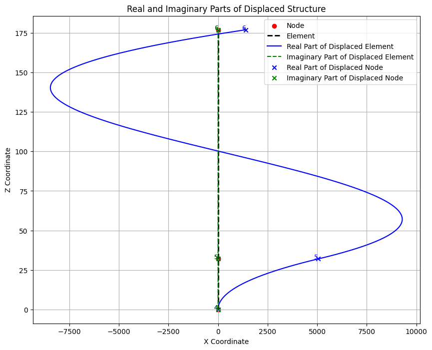

```python
#Normalising the modes of vibration and plotting the first 2

#firstly create a dictionary for storing the displacements of each mode
disp_dict = {}
disp_local_dict = {}
num = 8000
for omega in omega_m2:
    Kc_global = s2.GlobalConstrainedStiffness(omega)
    u_free = s2.SolveUfree(Kc_global[:-1,:-1], -Kc_global[:-1,-1])
    u_free = np.concatenate((u_free, np.array([1])))
    u_elem = s2.FullDisplacement(u_free)
    disp = s2.ElementDisplacements(u_elem, omega, num)
    disp_dict[omega] = disp
    # get local displacements
    disp_local = s2.ElementDisplacements(u_elem, omega,num,local_axes=True)
    disp_local_dict[omega] = disp_local

local_coordinates = get_local_coordinates(elems2, num)

def Normalize_modes2(Omega, displacement, displacement_local, local_coordinates, elements):
    disp_norm = {}
    disp_local_norm = {}
    for omega in Omega:
        Gamma = 0
        for element in elements:
            key = list(element.element_types.keys())[0]
            rho = element.element_types[key].rho
            A = element.element_types[key].A
            Gamma += rho * A * np.trapezoid(displacement_local[omega][element.id][1]**2, local_coordinates[element.id])
        Gamma += M * displacement_local[omega][element.id][1][-1]**2 #"element" is the last element from the loop, which is the upper one

        disp_norm[omega] = {elem: disp / np.sqrt(Gamma) for elem, disp in displacement[omega].items()}
        #Local normalised displacements
        disp_local_norm[omega] = {elem: disp / np.sqrt(Gamma) for elem, disp in displacement_local[omega].items()}
    return disp_norm, disp_local_norm

disp_norm, disp_local_norm = Normalize_modes2(omega_m2, disp_dict, disp_local_dict, local_coordinates, elems2)

for omega in omega_m2[:2]:
    s2.PlotElementDisplacements(disp_norm[omega], scale=1e7)
```

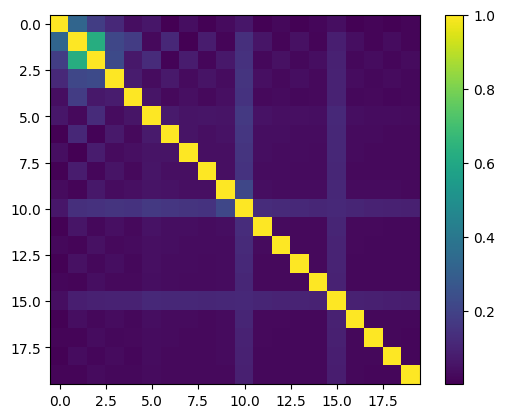

```python
#Checking the orthogonality of the modes

def Check_Orthogonality2(omega, disp_local_norm, local_coordinates, elements):
    N = len(omega)
    Ortho_matrix = np.zeros((N, N), dtype=complex)
    for ii, omega_1 in enumerate(omega):
        for jj, omega_2 in enumerate(omega):
            for element in elements:
                key = list(element.element_types.keys())[0]
                rho = element.element_types[key].rho
                A = element.element_types[key].A
                Ortho_matrix[ii, jj] += rho * A * np.trapezoid(disp_local_norm[omega_1][element.id][1] * disp_local_norm[omega_2][element.id][1], local_coordinates[element.id])
            Ortho_matrix[ii, jj] += M * disp_local_norm[omega_1][element.id][1][-1] * disp_local_norm[omega_2][element.id][1][-1] #"element" is the last element from the loop, which is the upper one
    return Ortho_matrix

Ortho_coeff = Check_Orthogonality2(omega_m2[:30], disp_local_norm, local_coordinates, elems2)

plt.imshow(abs(Ortho_coeff))
plt.colorbar();
```

### Creating the power spectral densities of the inputs

For the seismic motion, the provided power spectral density (PSD) can be used which is about the acceleration of the bedrock. It will be limited to a maximum frequency of 50 Hz, to avoid long computation times for frequencies that are not expected to create a response in the large and rigid structure. (A motion which happens 50 times per seconds seems unlikely to happen.)

For the power spectral density of the wave force, first a PSD of the wave heights is created using the provided JONSWAP spectrum, which was implemented in a function. For the inertia force according to the Morison equation, it holds that:

$$f_H(z,t) = \frac{1}{4}\pi D^2\rho_w\frac{\partial u}{\partial t} + \frac{1}{4}\pi D^2C_a\rho_w\left(\frac{\partial u}{\partial t} - \frac{\partial^2 w_2}{\partial t^2}\right)$$ $$f_H(z,t) = A_tC_M\rho_w\frac{\partial u}{\partial t} - A_tC_a\rho_w\frac{\partial^2 w_2}{\partial t^2}$$

[figure not shown]

with $C_M = 1 + C_a$. For the meaning of the other variables, see Exercise 4. The equations are about displaced mass, so the area should be taken as: $\frac{1}{4}\pi (D_{out}^2 - D_{inner}^2) = A_t$ as defined previously. When calculating the significant wave height from the JONSWAP spectrum and using that to calculate the Keulegan Carpenter (KC) number for deep water (which is assumed, to be able to use the easier formula), according to the formula $KC = \pi\frac{H}{D}$ with $H$ the significant wave height and $D$ the outer diameter of the offshore wind turbine, a KC number of 2.15 comes out. This means that the wave force indeed is inertia dominated so drag can safely be neglected, as was said in the assignment. Using a graph that relates KC numbers with the inertia coefficient $C_M$, it can be read that for an (assumed) smooth cylinder, the value of $C_M$ is around 2.05. $C_M = 1 + C_a$, and because the coefficient for added mass $C_a$ has an upper bound of 1, it will be given that upper bound value.

First, the JONSWAP spectrum should be converted to a PSD of the wave particle acceleration. The horizontal wave particle velocity and acceleration in regular "undeep" water are given by: $$u = \zeta_a\omega \frac{\cosh(k(d+z))}{\sinh(kd)} \cos(kx - \omega t)$$ $$\dot{u} = \zeta_a\omega^2 \frac{\cosh(k(d+z))}{\sinh(kd)} \sin(kx - \omega t)$$

with $\zeta_a = \frac{H}{2}$, and $H$ is what is represented by the JONSWAP spectrum. Furthermore, $k$ is the wave number and $z$ the considered depth ($z$ = -1 m is one meter under water). When only considering the amplitude of the wave and not the space and time dependent part, the relation between the wave height $H$ and the amplitude of the particle acceleration $\dot{u}$ reduces to:

$$\dot{u}_a = \frac{H}{2}\omega^2 \frac{\cosh(k(d+z))}{\sinh(kd)}$$

It means that the PSD of the wave particle acceleration is given by $S_{\dot{u}_a} = \alpha_1^2 S_{JS}$ in which $\alpha_1 = \frac{\omega^2}{2}$. The part of the formula with the wave number $k$ is not considered, because it results in overflows in the sinh and cosh function and there was no time to solve this (it was quickly tried using exponential functions and dividing the fraction by certain exponentials to end up with only negative powers, but this did not work; see commented code below). On top of that, it was at first sight unsure how to implement the acceleration that is changing with $z$ (depth). Due to those two facts, a constant unit distributed wave force along the offshore wind turbine will be assumed.

The second step relates this acceleration to the force according to the Morison equation: $S_F = \alpha_2^2 S_{\dot{u}_a}$ with $\alpha_2 = A_t C_M \rho_w$. This $S_F$ will be used in the following calculations and is called `PSD_waves_distr_force` in the code.

The other part of the inertia force, which is depending on the acceleration of the structure, can be incorporated in the system by increasing the cross-sectional density with $A_tC_a\rho_w$. Keeping the cross-sectional area at $A_t$, the original mass density should be increased with $C_a\rho_w$.

```
KC = 2.15 [-]
C_a = 1.0 [-]
```

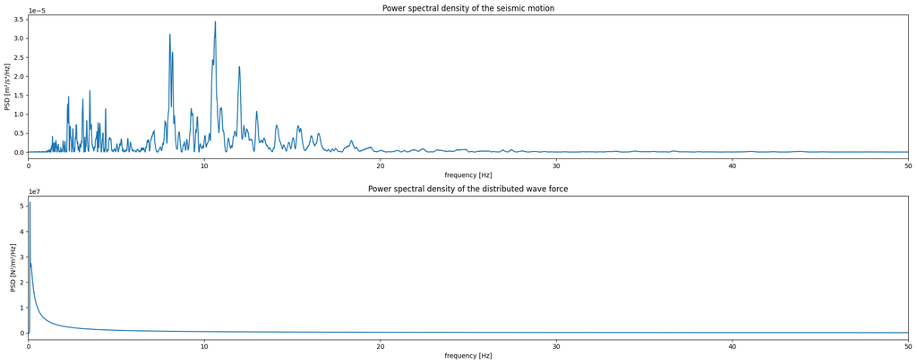

```python
#Calculating the power spectral densities (PSDs) in the correct units for both inputs

#Removing zero frequency value and limit to relevant frequencies
FRF_freq_max = 50
mask = (freq_seism > 0) & (freq_seism < FRF_freq_max)
FRF_freq = freq_seism[mask]
FRF_omega = FRF_freq * 2 * np.pi


#Converting PSD in [g²/Hz] to unit [m²/s⁴/Hz]
PSD_seism = PSD_seism_0[mask] * g**2


PSD_waves_height = JONSWAP(FRF_freq) #[m²/Hz]
alpha_1 = FRF_omega**2 / 2 #[s⁻²]
PSD_waves_acceleration = alpha_1**2 * PSD_waves_height #[m²/s⁴/Hz]

m_0 = np.trapezoid(PSD_waves_height, FRF_freq)
H_s = 4 * np.sqrt(m_0)
KC = np.pi * H_s / D_out
print(f'KC = {KC:.2f} [-]') #-> C_M > 2 for smooth cylinder

C_M = 2.05 #[-]
C_a = np.min([C_M - 1, 1]) #[-]
print(f'C_a = {C_a} [-]')
rho_w = 1025 #[kg/m³]
alpha_2 = A_t * C_M * rho_w #[kg/m]
PSD_waves_distr_force = alpha_2**2 * PSD_waves_acceleration #[kg²/s⁴/Hz] = [kg²m²/s⁴/m²/Hz] = [N²/m²/Hz]

plt.figure(figsize=(20, 8))
plt.subplot(2, 1, 1)
plt.plot(FRF_freq, PSD_seism)
plt.xlabel('frequency [Hz]')
plt.ylabel('PSD [m²/s⁴/Hz]')
plt.title('Power spectral density of the seismic motion')
plt.xlim(0, FRF_freq_max)

plt.subplot(2, 1, 2)
plt.plot(FRF_freq, PSD_waves_distr_force)
plt.xlabel('frequency [Hz]')
plt.ylabel('PSD [N²/m²/Hz]')
plt.title('Power spectral density of the distributed wave force')
plt.xlim(0, FRF_freq_max)
plt.tight_layout()


# #Calculation of wavenumbers (k)
# def omega_wave_number(k, g, d, omega):
#     return k * g * np.tanh(k * d) - omega**2

# k = np.zeros_like(FRF_omega)
# for i,om in enumerate(FRF_omega):
#     k[i] = fsolve(omega_wave_number, k[i - 1], args=(g, H_w, om))[0]

# diff = omega_wave_number(k, g, H_w, FRF_omega)
# print(len(diff[diff > 1e-10]) == 0)

# k_L = k[500:505] #here the original expression overflows
# k_L = k[869:875] #here the changed expression overflows
# zz = H_w / 2
# print(np.cosh(k_L * (H_w + zz)) / np.sinh(k_L * H_w))

# print((1 + np.exp(-k_L * (2 * H_w + 2 * zz))) / (np.exp(-k_L * zz) - np.exp(-2 * k_L * H_w - k_L * zz)))
```

### Determination of acceleration at the top of the offshore wind turbine

Only the (translational) acceleration at surface level is considered to transfer the response of the layered soil system to the offshore wind turbine model, because a rotational degree of freedom is not present in the shear beam definition that is used for the layered soil system. Otherwise, the response through surface rotational acceleration could have been added to the found response at the end of this section.

#### Acceleration at surface level due to seismic motion

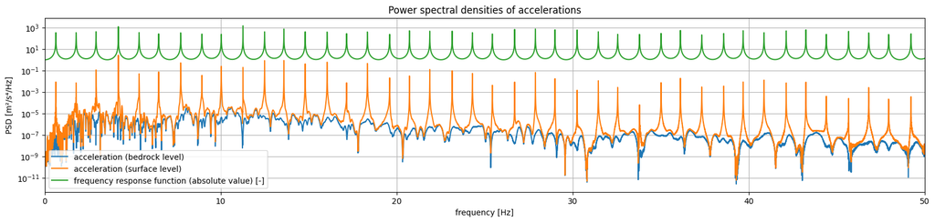

```python
#Calculating the FRF of unit seismic motion (acceleration) at bedrock level vs. acceleration at surface level and calculating and plotting the PSD of the response

FRF_seism_surface = np.zeros(len(FRF_omega), dtype=complex)

for i,omega in enumerate(FRF_omega):
    #Adding unit acceleration at bedrock level
    nodes1[-1].prescribe_node(x=1/-omega**2)
    s1.run_connectivity() #this is needed after fixing a node
    Kc_global = s1.GlobalConstrainedStiffness(omega)
    Fc_global = s1.GlobalConstrainedForce(omega)
    u_free = s1.SolveUfree(Kc_global, Fc_global)
    #first free dof (index 0) is the x-displacement of node 1 (index 0)
    FRF_seism_surface[i] = u_free[0] * -omega**2

#Units: [m²/s⁴/Hz] = [m/s²/(m/s²)]² * [m²/s⁴/Hz]
#Units: [m²/s⁴/Hz] = [     -     ]² * [m²/s⁴/Hz]
PSD_seism_surface = np.abs(FRF_seism_surface)**2 * PSD_seism

plt.figure(figsize=(20, 4))
plt.plot(FRF_freq, PSD_seism, label='acceleration (bedrock level)')
plt.plot(FRF_freq, PSD_seism_surface, label='acceleration (surface level)')
plt.semilogy(FRF_freq, np.abs(FRF_seism_surface), label='frequency response function (absolute value) [-]')
plt.xlabel('frequency [Hz]')
plt.ylabel('PSD [m²/s⁴/Hz]')
plt.title('Power spectral densities of accelerations')
plt.grid()
plt.legend()
plt.xlim(0, FRF_freq_max);
```

#### Acceleration at the top due to both loads

For both loads, a frequency response function can be calculated which relates the load to an acceleration at the top of the offshore wind turbine.

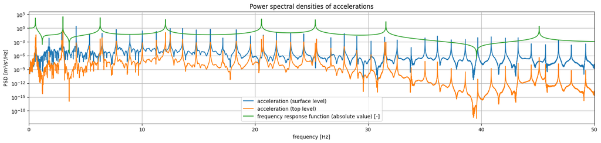

```python
#Calculating the FRF of unit seismic motion (acceleration) at surface level vs. 1) acceleration at the top of the OWT and 2) bending moment at the base of the OWT and calculating and plotting the PSD of the response of 1)

FRF_seism_top = np.zeros(len(FRF_omega), dtype=complex)
FRF_seism_base_M = np.zeros(len(FRF_omega), dtype=complex)

for i,omega in enumerate(FRF_omega):
    #Adding unit acceleration at surface level
    nodes2[0].prescribe_node(x=1/-omega**2)
    s2.run_connectivity() #this is needed after fixing a node
    Kc_global = s2.GlobalConstrainedStiffness(omega)
    Fc_global = s2.GlobalConstrainedForce(omega)
    F_global = s2.GlobalForce(omega)
    u_free = s2.SolveUfree(Kc_global, Fc_global)
    K_global = s2.GlobalStiffness(omega)
    support_reactions = s2.SupportReactions(K_global, u_free, F_global)

    #third free dof (index 2, in total 4 free dofs) is the x-displacement of the top of the OWT
    FRF_seism_top[i] = u_free[2] * -omega**2
    #second support reaction (index 1, in total 2 support reactions) is the bending moment at the base of the OWT
    FRF_seism_base_M[i] = support_reactions[1]

#Units: [m²/s⁴/Hz] = [m/s²/(m/s²)]² * [m²/s⁴/Hz]
#Units: [m²/s⁴/Hz] = [     -     ]² * [m²/s⁴/Hz]
PSD_seism_top = np.abs(FRF_seism_top)**2 * PSD_seism_surface

plt.figure(figsize=(20, 4))
plt.plot(FRF_freq, PSD_seism_surface, label='acceleration (surface level)')
plt.plot(FRF_freq, PSD_seism_top, label='acceleration (top level)')
plt.semilogy(FRF_freq, np.abs(FRF_seism_top), label='frequency response function (absolute value) [-]')
plt.xlabel('frequency [Hz]')
plt.ylabel('PSD [m²/s⁴/Hz]')
plt.title('Power spectral densities of accelerations')
plt.grid()
plt.legend()
plt.xlim(0, FRF_freq_max);
```

```
Successfully added element of type: EulerBernoulli Beam to Element 3
Successfully added element of type: EulerBernoulli Beam foundation attachments to Element 4
```

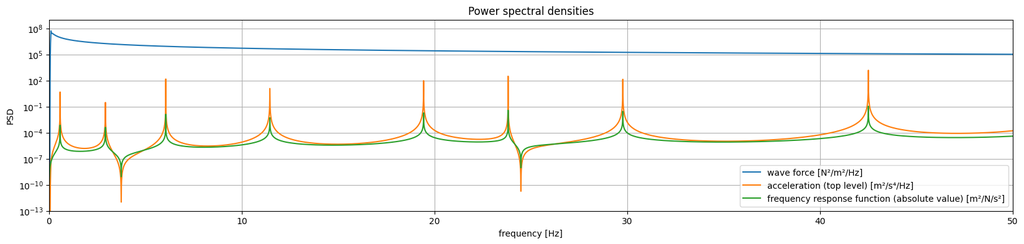

```python
#Calculating the FRF of unit wave load (distributed force) along the submerged part of the OWT vs. 1) acceleration at the top of the OWT and 2) bending moment at the base of the OWT and calculating and plotting the PSD of the response of 1)

FRF_waves_top = np.zeros(len(FRF_omega), dtype=complex)
FRF_waves_base_M = np.zeros(len(FRF_omega), dtype=complex)

#Adding a unit distributed force along the lower half of the offshore wind turbine (in the local coordinate system)
elems2[0].AddDistributedLoad(z=1)
#... and removing the unit acceleration at the bottom
nodes2[0].prescribe_node(x=0)

owt_section1_added_mass = owt_section1.copy()
owt_section1_added_mass['rho'] += C_a * rho_w
owt_section2_added_mass = owt_section2.copy()
owt_section2_added_mass['rho'] += C_a * rho_w

elems2[0].SetSection('EulerBernoulli Beam', owt_section1_added_mass)
elems2[1].SetSection('EulerBernoulli Beam foundation attachments', owt_section2_added_mass)

s2.run_connectivity() #this is needed after adding a load and changing geometry

for i,omega in enumerate(FRF_omega):
    Kc_global = s2.GlobalConstrainedStiffness(omega)
    Fc_global = s2.GlobalConstrainedForce(omega)
    F_global = s2.GlobalForce(omega)
    u_free = s2.SolveUfree(Kc_global, Fc_global)
    K_global = s2.GlobalStiffness(omega)
    support_reactions = s2.SupportReactions(K_global, u_free, F_global)
    #third free dof (index 2, in total 4 free dofs) is the x-displacement of the top of the OWT
    FRF_waves_top[i] = u_free[2] * -omega**2
    #second support reaction (index 1, in total 2 support reactions) is the bending moment at the base of the OWT
    FRF_waves_base_M[i] = support_reactions[1]

#Units: [m²/s⁴/Hz] = [m/s²/(N/m)]² * [N²/m²/Hz]
#Units: [m²/s⁴/Hz] = [  m²/N/s² ]² * [N²/m²/Hz]
PSD_waves_top = np.abs(FRF_waves_top)**2 * PSD_waves_distr_force

plt.figure(figsize=(20, 4))
plt.plot(FRF_freq, PSD_waves_distr_force, label='wave force [N²/m²/Hz]')
plt.plot(FRF_freq, PSD_waves_top, label='acceleration (top level) [m²/s⁴/Hz]')
plt.semilogy(FRF_freq, np.abs(FRF_waves_top), label='frequency response function (absolute value) [m²/N/s²]')
plt.xlabel('frequency [Hz]')
plt.ylabel('PSD')
plt.title('Power spectral densities')
plt.grid()
plt.legend()
plt.xlim(0, FRF_freq_max)
plt.ylim(10e-14, 10e8);
```

```
4.264874715226855
```

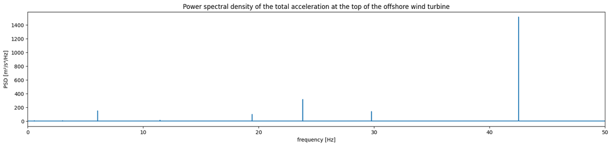

```python
#Calculating and plotting the resulting PSD of the acceleration at the top of the offshore wind turbine due to both loads

#Units: [m²/s⁴/Hz] = [m²/s⁴/Hz] + [m²/s⁴/Hz]
PSD_top = PSD_seism_top + PSD_waves_top

plt.figure(figsize=(20, 4))
plt.plot(FRF_freq, PSD_top)
plt.xlabel('frequency [Hz]')
plt.ylabel('PSD [m²/s⁴/Hz]')
plt.title('Power spectral density of the total acceleration at the top of the offshore wind turbine')
plt.xlim(0, FRF_freq_max)

std_top = np.sqrt(1 / np.pi * np.trapezoid(PSD_top, FRF_omega))
print(std_top)
```

### Determination of bending moment at the base of the offshore wind turbine

#### Bending moment at the base due to both loads

For both loads, a frequency response function can be calculated which relates the load to a bending moment at the base of the offshore wind turbine. To save computation time and changing the unit excitations back and forth between acceleration and distributed force, the FRF and resulting PSD were already computed above.

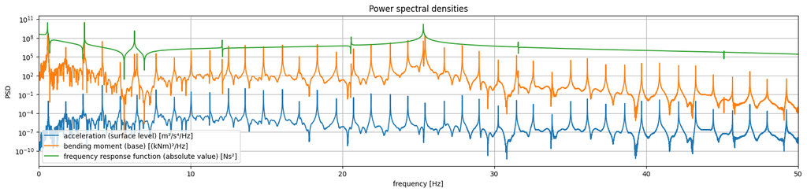

```python
#Calculating and plotting the PSD of the response of the bending moment at the base of the OWT due to seismic motion (acceleration)

#Units: [(kNm)²/Hz] = [Nm/(m/s²)]² * [m²/s⁴/Hz] * [kN/N]²
#Units: [(kNm)²/Hz] = [   Ns²   ]² * [m²/s⁴/Hz] * [kN/N]²
PSD_seism_base_M = np.abs(FRF_seism_base_M)**2 * PSD_seism_surface * (1e-3)**2 #to kNm

plt.figure(figsize=(20, 4))
plt.plot(FRF_freq, PSD_seism_surface, label='acceleration (surface level) [m²/s⁴/Hz]')
plt.plot(FRF_freq, PSD_seism_base_M, label='bending moment (base) [(kNm)²/Hz]')
plt.semilogy(FRF_freq, np.abs(FRF_seism_base_M), label='frequency response function (absolute value) [Ns²]')
plt.xlabel('frequency [Hz]')
plt.ylabel('PSD')
plt.title('Power spectral densities')
plt.grid()
plt.legend()
plt.xlim(0, FRF_freq_max);
```

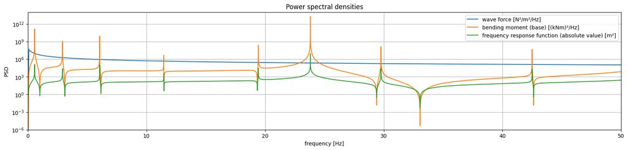

```python
#Calculating and plotting the PSD of the response of the bending moment at the base of the OWT due to wave force

#Units: [(kNm)²/Hz] = [Nm/(N/m)]² * [N²/m²/Hz] * [kN/N]²
#Units: [(kNm)²/Hz] = [   m²   ]² * [N²/m²/Hz] * [kN/N]²
PSD_waves_base_M = np.abs(FRF_waves_base_M)**2 * PSD_waves_distr_force * (1e-3)**2 #to kNm

plt.figure(figsize=(20, 4))
plt.plot(FRF_freq, PSD_waves_distr_force, label='wave force [N²/m²/Hz]')
plt.plot(FRF_freq, PSD_waves_base_M, label='bending moment (base) [(kNm)²/Hz]')
plt.semilogy(FRF_freq, np.abs(FRF_waves_base_M), label='frequency response function (absolute value) [m²]')
plt.xlabel('frequency [Hz]')
plt.ylabel('PSD')
plt.title('Power spectral densities')
plt.grid()
plt.legend()
plt.xlim(0, FRF_freq_max)
plt.ylim(10e-7, 10e13);
```

```
373685.8566200594
```

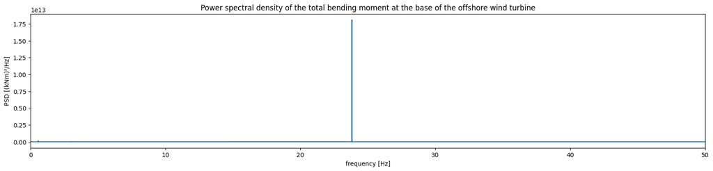

```python
#Calculating and plotting the resulting PSD of the bending moment at the base of the offshore wind turbine due to both loads

#Units: [(kNm)²/Hz] = [(kNm)²/Hz] + [(kNm)²/Hz]
PSD_base_M = PSD_seism_base_M + PSD_waves_base_M

plt.figure(figsize=(20, 4))
plt.plot(FRF_freq, PSD_base_M)
plt.xlabel('frequency [Hz]')
plt.ylabel('PSD [(kNm)²/Hz]')
plt.title('Power spectral density of the total bending moment at the base of the offshore wind turbine')
plt.xlim(0, FRF_freq_max)

std_base = np.sqrt(1 / np.pi * np.trapezoid(PSD_base_M, FRF_omega))
print(std_base)
```

### Responses: mean and standard deviation

For both acceleration at the top and bending moment at the base of the offshore wind turbine, it is a priori known that the mean is zero. This is because the both forces have a zero value at zero frequency, meaning that there is no static part of the forcing and only (dynamic) oscillations around the zero mean. This can be seen in the PSDs in the Defining the forcing section. On top of that, in the time history of the seismic motion a zero mean can be observed.

The standard deviations were computed above and are 4.3 m/s² for the top acceleration and 374 MNm for the bending moment at the base.

### Exceedance of safety thresholds

For the maximum allowable acceleration at the top of the offshore wind turbine, a value of 0.2 [g] = 1.96 [m/s²] is given. When using the calculated standard deviation and a normal distribution, the probability of exceedance of an acceleration of 1.96 [m/s²] is found as 65%.

For the maximum allowable bending/normal stress at the base of the offshore wind turbine, a value of 80% of 355 [N/mm²] is given. When calculating the probability of exceedance of this yield limit stress, first the static load of $(M + \rho_t \cdot A_t \cdot (H_w + H_t)) \cdot g$ that causes a static normal stress should be deducted from the limit value. Furthermore, the bending moment should be transformed into a stress. This is done using the formula:

$$\sigma = \frac{M_z z}{I_{zz}}$$

in which $M_z$, the bending moment about the z axis [Nm], is the found standard deviation, $z=\frac{D_{out}}{2}$ is the distance from the gravity center of the cross section to the outmost point [m] and $I_{zz}$ is the moment of inertia [m⁴].

Then, using this standard deviation and a normal distribution, it can be found that the probability of exceedance of a stress of 80% of 355 = 284 [N/mm²] is 0.2%.

For both calculations, a factor 2 is used to account for the fact that exceeding negative -0.2 [g] and -284 [N/mm²] also results in failure.

```python
print(f'acceleration: {2 * (1 - norm(0, std_top).cdf(0.2 * g)) * 100:.3f}%')

weight = (M + rho_t * A_t * (H_w + H_t)) * g #[N]
normal_stress_weight = weight / A_t * 1e-6 #[N/mm²]
print(normal_stress_weight)

std_base_sigma = (std_base * 1e3) * (D_out / 2) / I_t * 1e-6
print(std_base_sigma)
print(f'yield stress: {2 * (1 - norm(0, std_base_sigma).cdf(0.80 * 355 - normal_stress_weight)) * 100:.3f}%')
```

```
acceleration: 64.549%
17.68136415264938
83.99835552725808
yield stress: 0.152%
```

### Assumption of stationarity and ergodicity

Stationarity means that the statistical properties of the process do not change over time, e.g. the process is time invariant.

In the time series of both horizontal components of a Groningen earthquake (taken from the Matlab file `Ex01_Signals_comparison.m` from Lecture 5), it can be seen that the processes certainly are not time invariant: the amplitudes and thus variances (a statistical property) change over time. Amplitudes clearly increase at the arrival of surface waves around t=5 seconds.

[figure not shown]

On the other hand, wide-sense stationarity, as is mentioned in the assignment, is a correct assumption for Groningen earthquakes. They require a constant mean and a correlation function that only depends on the time difference between two considered time instances (Stanley Chan, [ECE 302: Lecture A.5 Wide Sense Stationary Processes](https://engineering.purdue.edu/ChanGroup/ECE302/files/Slide_A_05.pdf), 2020). In fact, the mean is constant with value 0, while the correlation can be assumed to only depend on the time difference.

Ergodicity means that two collections of the random variable far apart in the sequence are practically independent (Eric Zivot, [4 Time Series Concepts](https://bookdown.org/compfinezbook/introFinRbook/Time-Series-Concepts.html), 2022). Or, in other words, one sufficiently long realisation is assumed to contain information about the entire process (Andrei Metrikine, Random vibrations L1, 2025). In general, this assumption cannot be made, as the process is not very long and only a part of the time series of the ground acceleration above does not contain information about the entire time series.

### Correlation of vertical seismic excitation

If one would also consider seismic excitation acting in the vertical direction at the base of the offshore wind turbine, one could assume that the horizontal and vertical PSDs of the seismic motion are uncorrelated in the case of Groningen earthquakes.

This can best be shown using the Matlab file `Ex02_Fourier.m` from Lecture 5, in which the PSDs of North-South motion (major principal axis) and the vertical motion can be compared. For the measurements at different stations in the province of Groningen, e.g. FRB2 (Froombosch-2), HKS (Hoeksmeer) and STDM (Stedum), it can clearly be seen that frequencies at which relatively large peaks in one spectrum occur do not come with a (relatively) large amplitude in the other spectrum. As an example, the Hoeksmeer measurement is shown (left: North-South, right: vertical). The meanings of the abbreviations of the locations were taken from Table 2 on page 17 of "Validatie van het seismisch netwerk van het KNMI in Groningen", available for download here.

[figure not shown]